# OneMap tutorial - part 3

Scott Brainard

3/10/2021

```r
library(onemap) #version 2.2
load("clownfish2.rda")
```

As noted previously, OneMap can be used to construct genetic maps in F1 full-sib populations with any marker segregation types, and this includes multi-allelic markers, which will generally be more informative than biallelic markers. This tutorial demonstrates this capacity using the marker dataset from [Casas et al., 2018](https://www.nature.com/articles/s41598-018-22282-0), which analyzed a full-sib population of wild clownfish (Amphiprion bicinctus).

```r
clownfish <- read_onemap(dir = ".", inputfile = "batch_3.genotypes_50onemap_filtered_april2016.txt")
```

```
##  Working...
##
##  --Read the following data:
##  Type of cross:           outcross
##  Number of individuals:   94
##  Number of markers:       3147
##  Chromosome information:  no
##  Position information:    no
##  Number of traits:        0
```

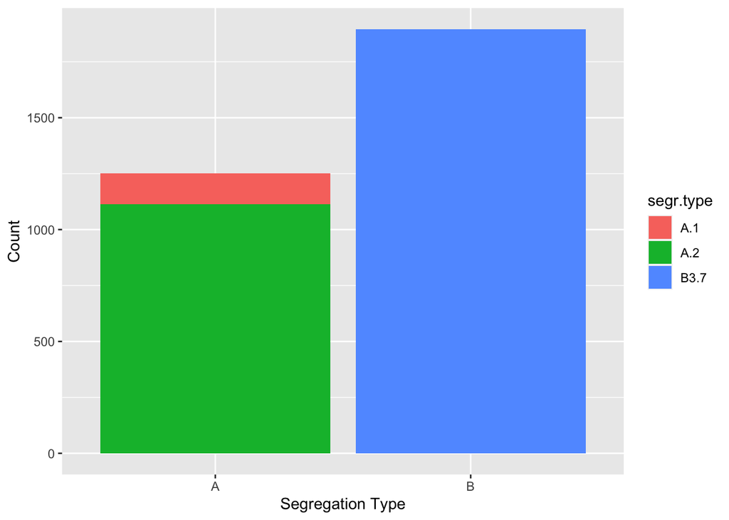

```r
plot_by_segreg_type(clownfish)
```

This marker dataset contains many B3.7 styles, but in addition, A.1 and A.2 type markers, which reflect abxcd and ab×ac segregation types, respectively.

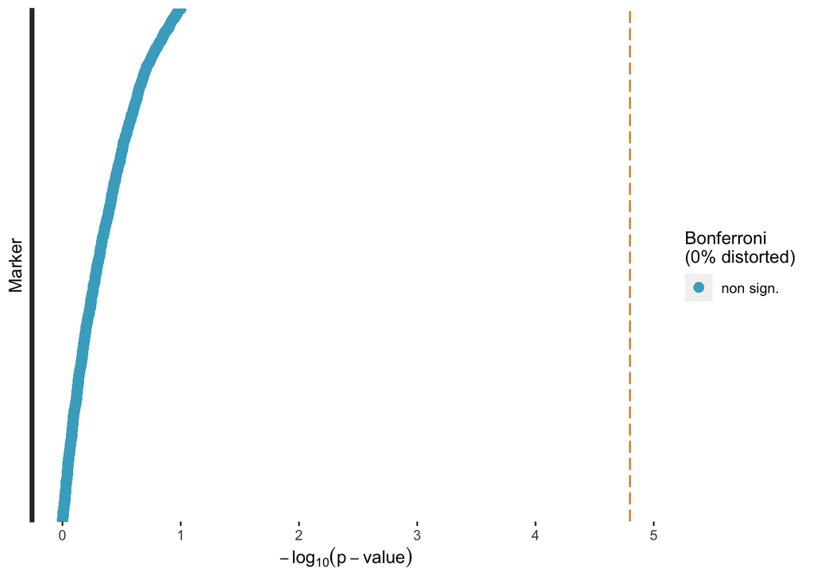

```r
clownfish.segreg_test <- test_segregation(clownfish)
plot(clownfish.segreg_test)
```

There is no segregation distortion, so we will proceed with all the markers.

```r
clownfish.twopts <- rf_2pts(clownfish, LOD = 4, max.rf = 0.4)
clownfish.markers <- make_seq(clownfish.twopts, "all")
clownfish.LGs <- group(clownfish.markers, LOD = 14, max.rf = 0.4 )
```

We will construct a map just as we did previously:

```r
set_map_fun(type="kosambi")
clownfish.LG1 <- make_seq(clownfish.LGs, 1)

clownfish.LG1.ord <- order_seq(clownfish.LG1, n.init=5, touchdown=TRUE)
clownfish.LG1.final <- make_seq(clownfish.LG1.ord,"force")
```

As we can see, the RF heatmap contains no whitespace.

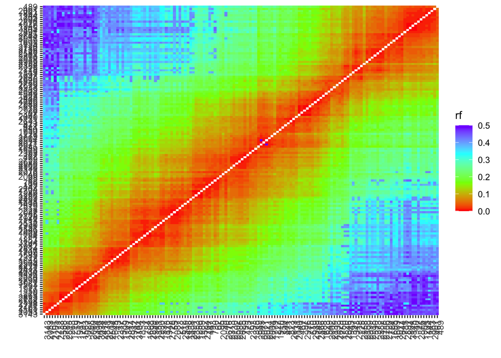

```r
rf_graph_table(clownfish.LG1.final, mrk.axis = "numbers")
```

It does, however, contain one marker that seems incorrectly placed, which we can remove using `drop_marker`:

```r
clownfish.LG1_drop_seq <- drop_marker(clownfish.LG1.final, 2914)
clownfish.LG1_remap <- map(clownfish.LG1_drop_seq)
```

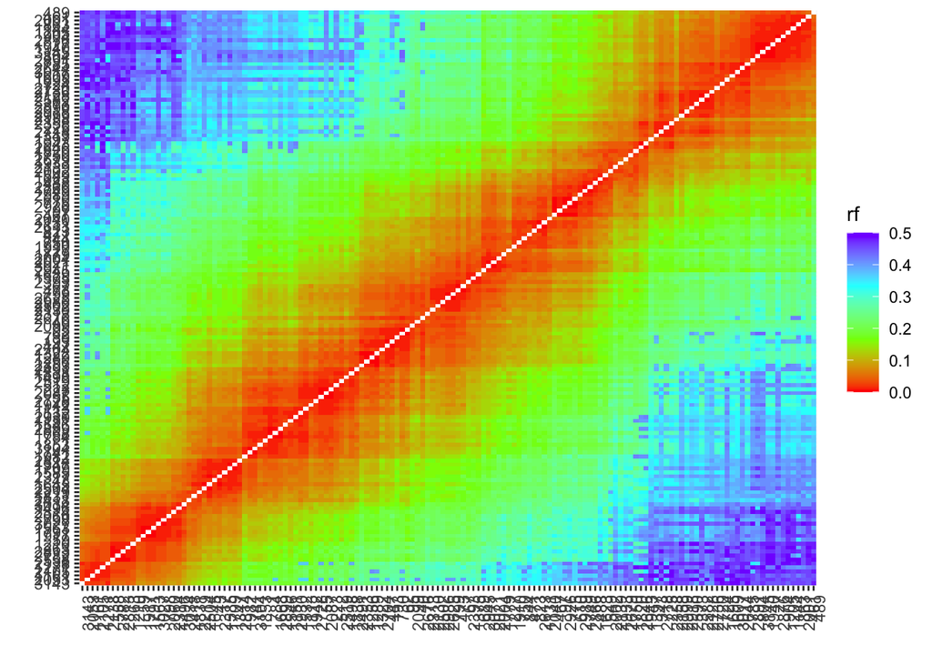

```r
rf_graph_table(clownfish.LG1_remap, mrk.axis = "numbers")
```

An alternative ordering strategy is to make use of [MDSMap](https://cran.r-project.org/web/packages/MDSMap/vignettes/MDSMap.pdf), a method for using multi-dimensional scaling to order markers in very high-density maps. `mds_onemap` implements this algorithm, which is fast, but only works well for large datasets. It is mainly designed to give good global orders, and thus `ripple_seq` is again a good option for evaluating local alternative orderings of markers.

```r
clownfish.LG1_mds <- mds_onemap(clownfish.LG1)
```

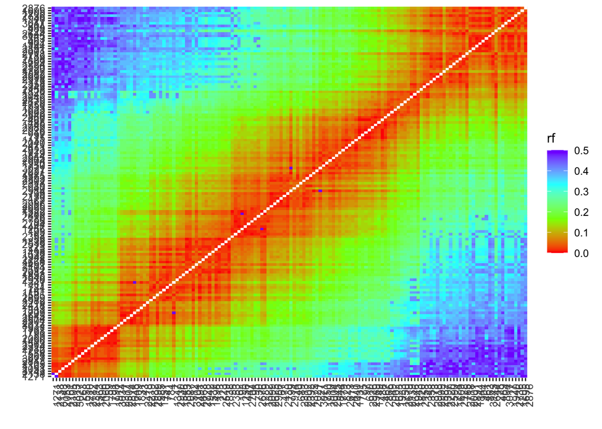

```r
rf_graph_table(clownfish.LG1_mds)
```

Again, the map seems very well-ordered, although there are several markers that may be misplaced (blue squares close to the diagonal), which could similarly be removed using `drop_marker`.